# Validating the smktrans transition probabilities

England

Duncan Gillespie, Sheffield Addictions Research Group

22 July 2026

# 1 What this report does and does not claim

There are two different things in here and they are not equally strong.

**Validation** is comparing our estimates against data that had no part in producing them. Throughout, the comparison years sit inside the model’s estimation window (initiation is estimated to 2017; 2018 onwards is forecast), and before the STS’s 2020 switch to telephone interviewing. So what is being tested is the estimation, on the years it was actually estimated, against a survey operating normally. Forecast performance is a different question and is not tested here; the one look we have taken at it, against the 2019-2023 waves, disagrees at the youngest ages in the direction a trend fitted to pre-2019 data has to disagree with a world where youth uptake turned up after 2020. That is a statement about the forecast and the data feeding it, not about the estimation.

There are two validations: quitting, in section 2, and net initiation, in section 3, both against the Smoking Toolkit Study.

**Verification** is checking that the pipeline does to its inputs what we think it does. That is `p_start` itself, and relapse entirely. It can tell us the code is behaving. It cannot tell us the answer is right.

The reason relapse only gets verification is that the Smoking Toolkit Study is a repeat cross-section. It never sees the same person twice, so it cannot observe anyone relapsing, which is a transition between two points in time for one person. There is no independent source we can put next to our relapse probabilities. They rest on one paper, Hawkins et al. 2010, and the most we can do is check that we have transcribed and transported it correctly.

Initiation sits in between. The STS cannot observe initiation either, for the same reason, but it can observe how the number of current smokers changes with age, and that change is initiation net of quitting and relapse. That is a real quantity and it is one we estimate, so section 3 is a genuine comparison - over the whole age range, on both sides of zero. The age where the net flow changes sign, where the cohort’s smoking prevalence peaks, is itself part of what is being compared. What this cannot do is separate the gross flows: it says nothing about `p_start` on its own.

# 2 Quitting against the Smoking Toolkit Study

We build the same quantity from the STS that our `p_quit` is: the probability that someone who was a smoker at the start of the year is not one at the end.

The STS asks smoking status as `smokstat`, which comes with four answers: smoking, stopped more than a year ago, stopped in the past year, and never smoked. So the people who were smoking a year ago are the ones smoking now plus the ones who stopped in the past year, and

$$p_{quit} = \frac{P(\text{stopped in past
year})}{P(\text{smoking now}) + P(\text{stopped in past
year})}$$

read straight off the survey-weighted proportions. The denominator is the counterfactual population: everyone who was in a position to quit.

Two things about how it is lined up against the model.

smktrans indexes `p_quit` on age at the **start** of the year, so someone observed at 40 who stopped in the past year is evidence about `p_quit(39)`, and so is a smoker observed at 40. Both go in at age minus one. On these data that choice moves the estimate by around 45%, so it is not a detail.

The years need lining up too, for the same sort of reason, and that is set out under the caveats below.

The denominator we can build is not quite the one we want, and this is why the plot starts at 25. Writing the states at the start of the year as S (smoking), F (former) and V (never), what we can count is

$$|S| + |F \rightarrow S| + |V \rightarrow
S|$$

when `p_quit` wants $|S|$ alone. Turning the recent quitters back on adds $S \rightarrow F$ back where it belongs, but nothing removes the people who were **not** smoking a year ago and are smoking now: relapsers, and at young ages people who had never smoked and have just started. The STS has no variable for when a current smoking spell began, so they cannot be found. The denominator is too big and the STS estimate comes out too low.

A synthetic cohort run through our own 2019 probabilities puts a number on it. From 26 upwards it is 1 to 5%, comfortably inside the bootstrap interval and not worth worrying about, and nearly all of it is relapsers. Below 25 it is 23%, a third of that is new smokers rather than relapsers, and at 18 it reaches 28%. A comparison that is 28% out by construction is not a comparison, so the plot starts where the arithmetic holds.

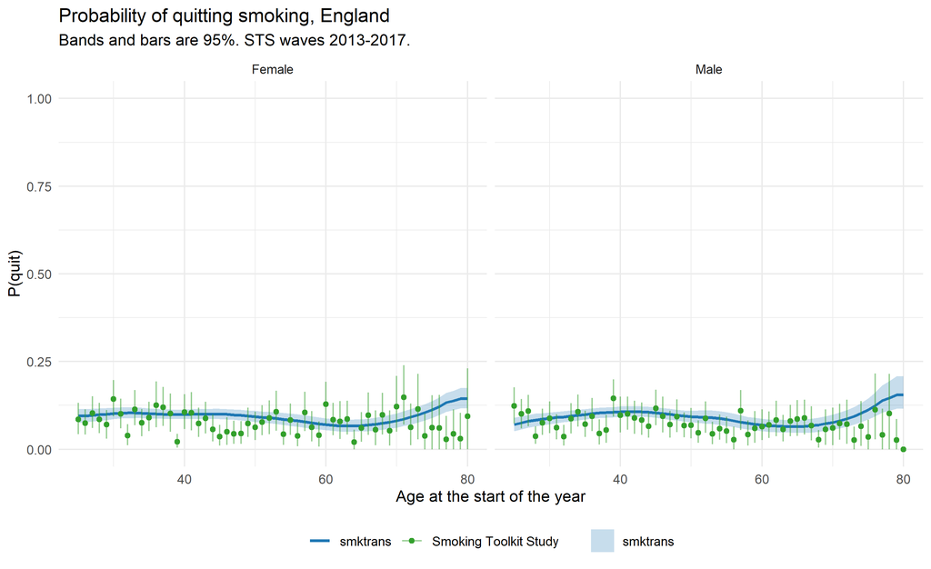

| Model year | Exposure (wave-years) | Weight |
| --- | --- | --- |
| 2012 | 5.5 | 0.092 |
| 2013 | 12.0 | 0.200 |
| 2014 | 12.0 | 0.200 |
| 2015 | 12.0 | 0.200 |
| 2016 | 12.0 | 0.200 |
| 2017 | 6.5 | 0.108 |

| Sex | Ages compared | smktrans inside STS 95% | Median difference | Mean absolute difference | Correlation over age |
| --- | --- | --- | --- | --- | --- |
| Female | 56 | 73% | +0.0134 | 0.0333 | -0.148 |
| Male | 56 | 73% | +0.0159 | 0.0313 | -0.118 |

## 2.1 What to be careful about

The STS estimate is not assumption-free either. Four things carry through into the comparison above.

**The years the STS reports on are not the years its waves are fielded in.** It asks whether someone stopped in the last twelve months, not whether they stopped during a particular calendar year. So a wave fielded in March 2019 is reporting on quits going back to March 2018, and nine of those twelve months are 2018. Pooling all of 2019’s waves observes five and a half years’ worth of 2018 and six and a half of 2019.

The model is therefore averaged over the years the window actually covers, weighted by how much of each one the survey saw, rather than over the years the waves are stamped with. The weights are in the table above.

The only wave selection that would land exactly on whole calendar years is December waves alone, since a December interview looks back over that calendar year and no further. That is genuinely exact and it throws away eleven twelfths of the sample, which widens the intervals three and a half times and leaves a plot that says nothing. The weighting is worth 0.9% here, under a fiftieth of the confidence interval, so this is a correction that costs nothing and buys very little. It is applied because it is free and because the next person to widen the year range will get a larger number without knowing to look for it.

Waves are mapped to calendar years arithmetically, anchored on wave 150 being March 2019, which puts wave 1 in October 2006. That checks out against the old code: it filtered `xwave >= 148` and called it “2019-”, and wave 148 is January 2019 under this mapping. Only whole years are used, so a part-covered year is dropped rather than contributing a seasonally biased average.

The model side is averaged over IMD and year using ONS populations, because the STS figure is a population average and a plain mean over the subgroups is not the same thing. The population file stops at 2019, so for later years we hold that year’s age, sex and IMD structure.

# 3 Net initiation against the Smoking Toolkit Study

`calculate_net_initiation` produces

$$p_{start}^{net}(a) =
\frac{n_{current}(a+1) - n_{current}(a)}{n_{never}(a) +
n_{former}(a)}$$

and because never, current and former sum to a constant, the denominator is just the people who are not currently smoking. Dividing through gives

$$p_{start}^{net}(a) = \frac{prev(a+1) -
prev(a)}{1 - prev(a)}$$

which we can compute from STS prevalence two ways. A single cross-section differences prevalence over age, but its gradient compares different birth cohorts, and with initiation having fallen the older cohorts carry more smoking, so it overstates net initiation at older ages - exactly where the model is being judged. With five survey years we can instead follow the same cohort from one year to the next, prev(a+1, t+1) against prev(a, t), which cancels the cohort effect by construction. The cohort-followed series is the primary comparison; the cross-section is plotted as open circles so the size of the cohort effect is visible rather than asserted.

Following cohorts matches the rates but not the stocks, and that limits what this comparison can test. The model runs a separate synthetic cohort for each year, so its stocks at age $a$ are those of a lifetime lived under that one year’s rates; the STS diagonal follows a real cohort whose stocks carry the history of higher initiation a decade earlier. Under secular decline the synthetic current-smoker stock is smaller at every age past about 20, the quit outflow with it, and the model sits above (less negative than) the diagonal at 25+ even when every probability in it is right - roughly $p_{quit} \times (prev_{real} - prev_{synth})/(1 - prev)$, about 0.010 at 25-30, the size of the gap seen below. The diagonal additionally absorbs composition change (migration and response drift between waves) that the closed synthetic cohort excludes, and its 16-17 points are boundary derivatives of a smoothed curve. So this section reads in two registers: at ages 16-24 the two sides measure close to the same thing and interval coverage is a test; at 25+ the comparison is descriptive, and the documented estimand gap - not model error - is the expected explanation for the model sitting above the dots.

Net initiation goes negative past the age where smoking prevalence peaks, which is a real feature of the age profile rather than something to hide, so the comparison runs over the whole range and both sides are free to fall below zero.

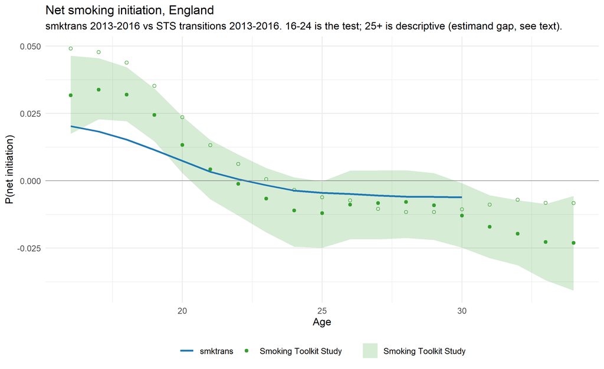

| Measure | Value |
| --- | --- |
| Ages compared | 15 (16-30) |
| Inside the STS 95% interval, ages 16-24 (the test) | 67% (6 of 9) |
| Median difference, full range | +0.00198 |
| Correlation over age, full range | 0.986 |
| Transition years compared | 2013-2016 |

The prevalence curve is smoothed over age before it is differenced, rather than differenced and then repaired.

# 4 Relapse against the Hawkins inputs

This is verification and not validation. Hawkins et al. 2010 is our input, so comparing our output back to it cannot tell us whether our relapse probabilities are right. It tells us whether the pipeline is doing what we think.

The check that does the work is an invariant rather than a comparison. `prep_relapse` computes a weighted average of Hawkins values over the demographic profile, and a weighted average cannot fall outside the range of the things it averages. So for every combination of time since quit, age, sex and IMD, our output has to sit inside the minimum and maximum of Hawkins across the covariate combinations. Historically that is a hard invariant and a failure is a bug. For forecast years it is not, because `relapse_forecast` deliberately scales by the fitted trend and may legitimately leave the range.

```
## Hawkins envelope: 9790 cells, 160 covariate combinations each.
```

```
##
## -- prep_relapse output, historical --
```

```
## 0 of 108000 cells (0.00%) outside the Hawkins envelope, years 2003-2017.
```

```
##
## -- final output, historical (scaling is 1 at and before the jump-off year) --
```

```
## 0 of 118500 cells (0.00%) outside the Hawkins envelope, years 2003-2017.
```

```
##
## -- final output, forecast --
```

```
## 0 of 181700 cells (0.00%) outside the Hawkins envelope, years 2018-2040.
```

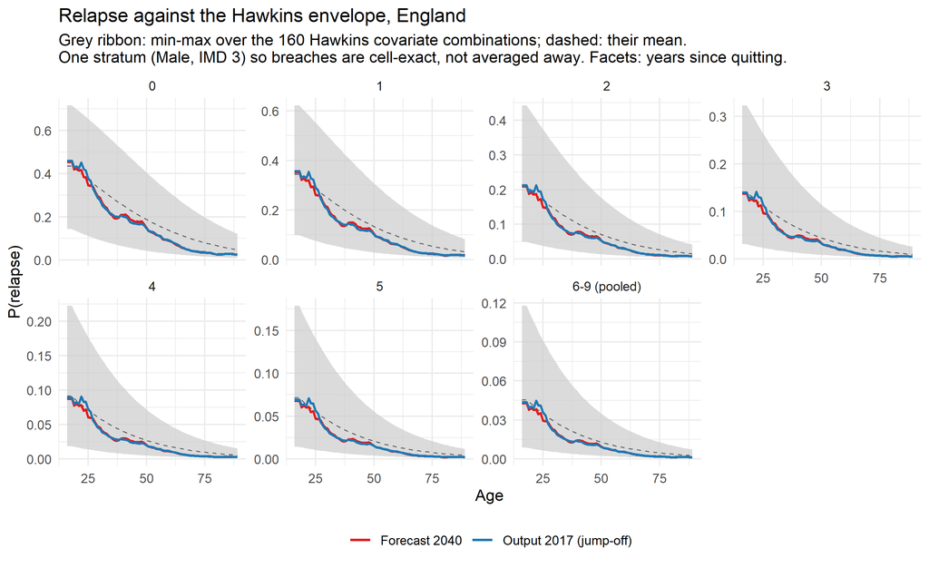

```
##
## --- Effect of re-weighting Hawkins onto England's demographic profile ---
##     (our output relative to the unweighted Hawkins mean, jump-off year)
##
## Key: <time_since_quit>
##     time_since_quit ratio_median ratio_q05 ratio_q95
##               <int>        <num>     <num>     <num>
##  1:               0        0.704     0.443     0.981
##  2:               1        0.683     0.432     0.958
##  3:               2        0.657     0.423     0.924
##  4:               3        0.644     0.419     0.907
##  5:               4        0.638     0.416     0.899
##  6:               5        0.636     0.415     0.895
##  7:               6        0.632     0.414     0.891
##  8:               7        0.632     0.414     0.891
##  9:               8        0.632     0.414     0.891
## 10:               9        0.632     0.414     0.891
##
##   A ratio below 1 means England's profile is lower-relapse than the average
##   Hawkins respondent. A ratio that varies a lot across tsq means the covariate
##   effects interact with time since quit.
##
## --- Relapse over time since quit ---
##
## Key: <time_since_quit>
##     time_since_quit    hawkins     output
##               <int>      <num>      <num>
##  1:               0 0.23037159 0.16382874
##  2:               1 0.17255034 0.11551761
##  3:               2 0.09879620 0.06075116
##  4:               3 0.06422756 0.03782258
##  5:               4 0.04067435 0.02322475
##  6:               5 0.03160435 0.01782703
##  7:               6 0.01991164 0.01105326
##  8:               7 0.01991164 0.01105326
##  9:               8 0.01991164 0.01105326
## 10:               9 0.01991164 0.01105326
## 11:              10 0.00000000 0.00000000
##
##   tsq 9 -> 10: 0.0111 -> 0.0000. Relapse is set to exactly zero at 10 years
```

[output cut: 10 more lines]

```
##               <int>     <num>       <num>           <num>           <num>
##  1:               0        NA       23.04              NA              NA
##  2:               1      15.1       17.26             227            1578
##  3:               2       7.9        9.88              95            1128
##  4:               3       4.9        6.42              48             832
##  5:               4       3.0        4.07              25             645
##  6:               5       2.3        3.16              16             535
##  7:               6       1.1        1.99               6             410
##  8:               7       1.4        1.99               6             317
##  9:               8       0.3        1.99               1             254
## 10:               9       1.3        1.99               4             213
## 11:              10       0.0        0.00               0             180
##
##   Largest difference in year-on-year ratio, years 1-5: 0.049
##   tsq 0 vs tsq 1 odds ratio: 1.5337 (Jackson implies 1.5337, mean abstinence 21.2 weeks)
```

## 4.1 What this cannot check

The relapse module rests entirely on one paper and one cohort: 1,578 people in the British Household Panel Survey between 1991 and 2006. Everything above confirms we are using it consistently. None of it confirms that those estimates describe England in the 2020s.

Three things are worth noting:

The baseline is calibrated rather than published. Hawkins reports odds ratios but not the intercept of its model, so we solve for the baseline that makes the Hawkins cohort reproduce the paper’s own Table 2. That solve assumes the covariates are independent of each other, which they are not, and assumes an age distribution matching the mean and standard deviation implied by Table 1. Getting that age distribution wrong is easy and it moves the answer: the correction is 1.07 done properly and 1.20 if the distribution is truncated carelessly. Once the moments are matched the shape barely matters, and five different shapes all land between 1.072 and 1.076. Before calibration the table gave the Hawkins cohort 14.28% relapsing at one year against the paper’s 15.10%.

Relapse is set to exactly zero at ten years, with no uncertainty attached, and the ABM cannot tell that apart from a finding. It is a convention. The paper’s own Kaplan-Meier curve is still declining past ten years, and the zero in Table 2 rests on no relapses out of 180 people in a single year.

Ages under 18 take the age-18 values, which are the highest in the series.

# 5 Where this leaves things

What this does not cover, deliberately: the forecast years, which are known to miss the post-2020 turn in youth uptake because the survey feeding the trend ends in 2018; and the level of relapse, which rests on Hawkins et al. alone. Those are the two places any remaining worry should live. The STS decline in prevalence at ages 31-34, visible past the end of the model line in section 3, is close to a pure quit-versus-relapse quantity and would give relapse an external check if the initiation pipeline were extended past age 30. This will need to be addressed when new, post-COVID, years of data are added to the estimation process.

# 6 Summary

[output not shown]

| Item | Value |
| --- | --- |
| R version | R version 4.6.0 (2026-04-24 ucrt) |
| smktrans | 2.3.0 |
| data.table | 1.18.4 |
| Report run | 2026-07-22 12:35 |
| Bootstrap seed | 20260716 |
| Bootstrap draws | 1000 |